# Correction des exercices

# Chapitre 4

On commence par charger les packages en mémoire si besoin, puis par importer les données.

```r
# Mise en mémoire des packages
library(dplyr)
library(ggplot2)
library(readxl)
library(palmerpenguins)

# Importation des données
dauphin <- read_excel("dauphin.xls", na = "*", skip = 9)

# Modification des noms de variables
names(dauphin) <- c("ID", "Sexe", "Statut", "Taille",
                    "Age", "Cd", "Cu", "Hg", "Organe")
```

## Exercice 4.2.5

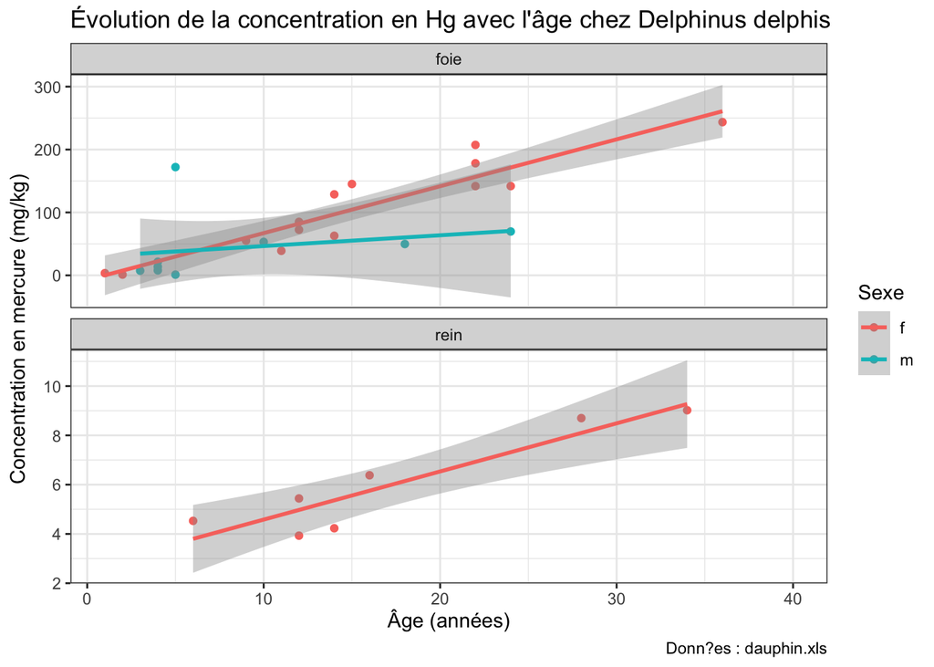

```r
ggplot(dauphin, aes(Age, Hg, colour = Sexe)) +
  geom_point() +
  geom_smooth(method = "lm") +
  facet_wrap(~ Organe, ncol = 1, scales = "free_y") +
  labs(title = "Évolution de la concentration en Hg avec l'âge chez Delphinus delphis",
       x = "Âge (années)",
       y = "Concentration en mercure (mg/kg)",
       caption = "Donn?es : dauphin.xls") +
  theme_bw()
```

## Exercice 4.5.2

```r
adelie_light <- penguins %>%
  filter(species == "Adelie",
         body_mass_g <= 3700)

adelie_light
```

```
# A tibble: 81 × 8
   species island    bill_length_mm bill_depth_mm flipper_…¹ body_…² sex    year
   <fct>   <fct>              <dbl>         <dbl>      <int>   <int> <fct> <int>
 1 Adelie  Torgersen           40.3          18          195    3250 fema…  2007
 2 Adelie  Torgersen           36.7          19.3        193    3450 fema…  2007
 3 Adelie  Torgersen           39.3          20.6        190    3650 male   2007
 4 Adelie  Torgersen           38.9          17.8        181    3625 fema…  2007
 5 Adelie  Torgersen           34.1          18.1        193    3475 <NA>   2007
 6 Adelie  Torgersen           37.8          17.1        186    3300 <NA>   2007
 7 Adelie  Torgersen           37.8          17.3        180    3700 <NA>   2007
 8 Adelie  Torgersen           41.1          17.6        182    3200 fema…  2007
 9 Adelie  Torgersen           36.6          17.8        185    3700 fema…  2007
10 Adelie  Torgersen           38.7          19          195    3450 fema…  2007
# … with 71 more rows, and abbreviated variable names ¹flipper_length_mm,
#   ²body_mass_g
```

## Exercice 4.7.2

*Question 1* :

```r
library(ggplot2)
View(mpg)
help(mpg)
```

Les variables `cty` (“city miles per gallon”) et `hwy` (“highway miles per gallon”) nous renseignent sur la consommation des véhicules. La variable `displ` représente la cylindrée (volume du moteur), en litres (“engine displacement, in litres”)

*Question 2* :

En considérant qu’il s’agit de gallons américains (1 gallon = 3,78541 litres), et que 1 mile = 1,60934 km :

```r
mpg <- mpg %>%
  mutate(conso = (3.78541 / 1.60934 * 100) / hwy)

mpg
```

```
# A tibble: 234 × 12
   manufactu…¹ model displ  year   cyl trans drv     cty   hwy fl    class conso
   <chr>       <chr> <dbl> <int> <int> <chr> <chr> <int> <int> <chr> <chr> <dbl>
 1 audi        a4      1.8  1999     4 auto… f        18    29 p     comp…  8.11
 2 audi        a4      1.8  1999     4 manu… f        21    29 p     comp…  8.11
 3 audi        a4      2    2008     4 manu… f        20    31 p     comp…  7.59
 4 audi        a4      2    2008     4 auto… f        21    30 p     comp…  7.84
 5 audi        a4      2.8  1999     6 auto… f        16    26 p     comp…  9.05
 6 audi        a4      2.8  1999     6 manu… f        18    26 p     comp…  9.05
 7 audi        a4      3.1  2008     6 auto… f        18    27 p     comp…  8.71
 8 audi        a4 q…   1.8  1999     4 manu… 4        18    26 p     comp…  9.05
 9 audi        a4 q…   1.8  1999     4 auto… 4        16    25 p     comp…  9.41
10 audi        a4 q…   2    2008     4 manu… 4        20    28 p     comp…  8.40
# … with 224 more rows, and abbreviated variable name ¹manufacturer
```

*Question 3* :

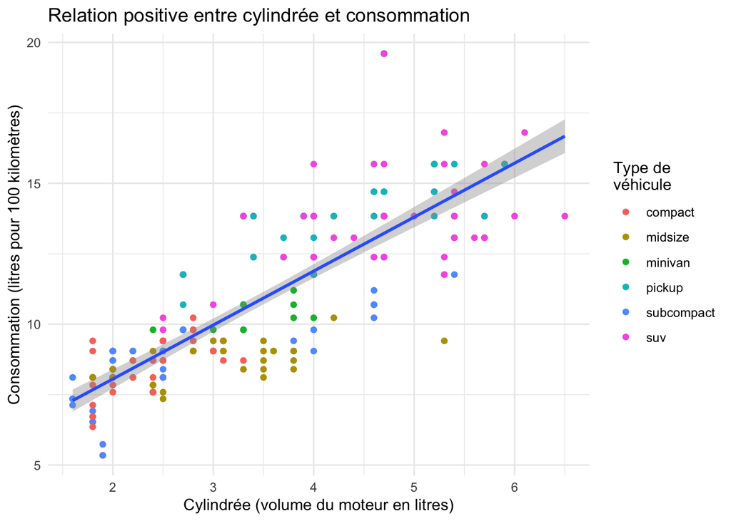

```r
mpg %>%
  filter(class != "2seater") %>%
  ggplot(aes(x = displ, y = conso)) +
  geom_point(aes(colour = class)) +
  geom_smooth(method = "lm") +
  labs(title = "Relation positive entre cylindrée et consommation",
       x = "Cylindrée (volume du moteur en litres)",
       y = "Consommation (litres pour 100 kilomètres)",
       colour = "Type de\nvéhicule") +
  theme_minimal()
```

*Question 4* :

Ce graphique masque les données répétées : s’il y a deux points avec les mêmes valeurs pour x et pour y, on ne peut pas le voir. Il faut remplacer `geom_point()` par `geom_jitter()` pour que les points qui se superposent apparaissent côte à côte. On peut en outre changer la forme des points en ajoutant `shape = 21`, et utiliser `fill = class` au lieu de `colour = class`, car c’est maintenant l’intérieur des points qui est coloré et non leur contour (la symbole 21 permet de distinguer couleur de remplissage et couleur de contour).

Cela donne le code ci-dessous :

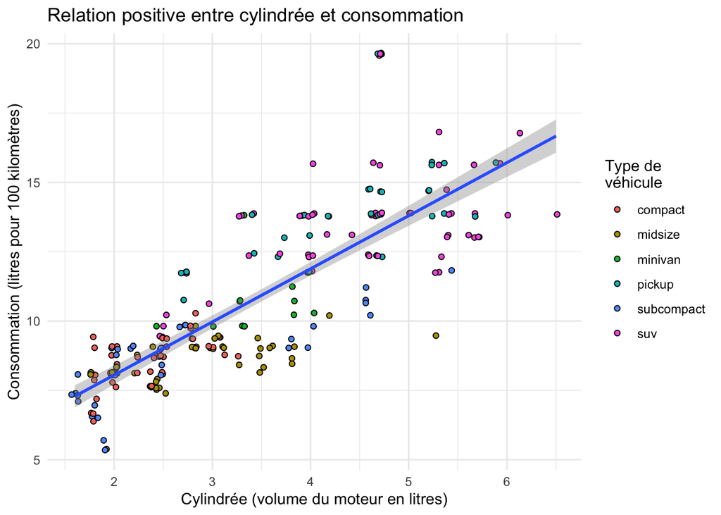

```r
mpg %>%
  filter(class != "2seater") %>%
  ggplot(aes(displ, conso)) +
  geom_jitter(aes(fill = class), shape = 21) +
  geom_smooth(method = "lm") +
  labs(title = "Relation positive entre cylindrée et consommation",
       x = "Cylindrée (volume du moteur en litres)",
       y = "Consommation (litres pour 100 kilomètres)",
       fill = "Type de\nvéhicule") +
  theme_minimal()
```

L’avantage de ce nouveau graphique est qu’il permet de voir tous les points. L’inconvénient est que pour voir tous les points, il a fallu modifier légèrement toutes les valeurs pour les 2 variables (cylindrée et consommation).